### Data Introduction

This data was acquired form FishBase (Froese and Pauley 2000) using the rfishbase package (Boettiger et al., 2012; see data_acquisition.R for data retrieval).

The data set includes the following variables:

- `species`: the scientific name of fish
- `genus`: the scientific genus of fish
- `common_name`: common name used for fish
- `body_shape`**: shape of fish body (elongated, fusiform/normal, eel-like, short and/or deep, other)**
- `habitat`**: area of the ocean that fish typically resides in**
- `depth_range_shallow`**: minimum depth fish is found**
- `depth_range_deep`**: maximum depth fish is found**
- `vulnerability`**: metric for how at risk a fish is to over fishing based on other life history and ecological traits**
- `length`**: total length, fork length, or standard length of fish**
- `trophic_level`**: trophic level that the fish occupies based on position in food web**
- `food_troph`: trophic level that fish’s food source occupies
- `food`**: type of food source fish consumes**
- `family`: the scientific family of fish

*Bold variables are included in the models. A full copy of the codebook is included in the data/raw folder*

#### Habitat Types

This project attempts to predict 8 different habitat types. These habitats are described below to note differences.

1. pelagic: living within several regions of the pelagic zone, through both shallower pelagic-oceanic and deeper bathypelagic
2. pelagic-neritic: relating to upper layers of the ocean on the continental shelf. Waters here are not as deep as the pelagic zone
3. reef-associated: living in association with a coral reef. This habitat is the most diverse, offering an array of food types and shelters
4. demersal: relating to living on or near the ocean floor, whether in the pelagic-neritic, pelagic, or bathypelagic zones
5. benthopelagic: relating specifically to the ocean floor in the pelagic zone, but not at the deepest depths
6. bathydemersal: relating to the ocean floor at depths greater than 200 meters
7. pelagic-oceanic: relating specifically to the upper layers of the open ocean. Food is scarce
8. bathypelagic: relating to deeper layers of the open ocean at the continental slope. Limited sunlight reaches this zone

While there is some possible overlap in these categories, they are kept separate as specifically defined in FishBase. Data has already been pre-processed for you.

#### Data Cleaning

Today, we are going to use all habitats!

```r
fish_clean = read_csv(here("discussion", "data", "fish_clean.csv")) %>%
  mutate(habitat = as.factor(habitat))
```

### Modeling

Today, we will look at preforming Random Forest and Boosted Trees on this data set. We will continue to come back to this data set as we learn more models in this section.

#### Training and Testing Data Creation

Here, we will use functions from the `rsample` package within `TidyModels`

```r
data_split = initial_split(fish_clean, prop = .8, strata = habitat) #split data stratified by survived

train = training(data_split)#get training data
test = testing(data_split) #get testing data

head(train)
```

```
## # A tibble: 6 × 11
##   genus  species habitat vulnerability family trophic_level_impute length_impute
##   <chr>  <chr>   <fct>           <dbl> <chr>                 <dbl>         <dbl>
## 1 Abyss… Abysso… bathyd…          33.0 Cotti…                 3.92          12.6
## 2 Abyss… Abysso… bathyd…          35.5 Cotti…                 3.92          14
## 3 Acant… Acanth… bentho…          51.9 Serra…                 4.07          60
## 4 Acant… Acanth… bentho…          31.1 Cepol…                 3.47          35
## 5 Acant… Acanth… bentho…          28.1 Cepol…                 3.47          30
## 6 Acant… Acanth… bentho…          28.6 Steph…                 3.57          14.1
## # ℹ 4 more variables: shallow_impute <dbl>, deep_impute <dbl>,
## #   shape_impute <chr>, food_impute <chr>
```

```r
head(test)
```

```
## # A tibble: 6 × 11
##   genus  species habitat vulnerability family trophic_level_impute length_impute
##   <chr>  <chr>   <fct>           <dbl> <chr>                 <dbl>         <dbl>
## 1 Abali… Abalis… pelagi…          39.8 Balis…                 3.64          32.5
## 2 Abali… Abalis… reef-a…          43.8 Balis…                 3.64          60
## 3 Abali… Abalis… demers…          43.8 Balis…                 3.64          60
## 4 Abude… Abudef… reef-a…          28.2 Pomac…                 2.81          17
## 5 Abude… Abudef… reef-a…          30.4 Pomac…                 3.03          20
## 6 Abude… Abudef… reef-a…          15.8 Pomac…                 2.57          20
## # ℹ 4 more variables: shallow_impute <dbl>, deep_impute <dbl>,
## #   shape_impute <chr>, food_impute <chr>
```

```r
cv_folds = vfold_cv(train, v = 5)
```

#### Recipe Creation

After splitting my data, the first step is to create a recipe indicating the formula for the model and any pre-processing steps I want to preform on my data. Here we will use the `recipes` package.

I will be predicting habitat based on trophic level, length, minimum depth, maximum depth, vulnerability, body shape, and food source type. We will be normalizing all numeric predictors

```r
fish_recipe = recipe(habitat ~ shape_impute + food_impute + shallow_impute + deep_impute + vulnerability + length_impute + trophic_level_impute, data = train) %>% #create model recipe
  step_dummy(all_nominal_predictors()) %>% #create dummy variables from all factors
  step_normalize(all_numeric_predictors()) #normalize all numeric predictors
```

#### Model 4: Random Forest Classifier

```r
?rand_forest
```

I will be using the ranger engine (Wright 2017) for this model. The parameters I will be tuning are mtry and trees. mtry is the number of predictors that will be randomly sampled for use in each of the trees created. trees is the number of tress that the model creates.

```r
rf_model <- rand_forest(mtry = tune(), trees = tune()) %>%
  set_engine("ranger") %>%
  set_mode("classification")
```

```r
rf_workflow = workflow() %>%
  add_model(rf_model) %>%
  add_recipe(fish_recipe)

rf_workflow
```

```
## ══ Workflow ════════════════════════════════════════════════════════════════════
## Preprocessor: Recipe
## Model: rand_forest()
##
## ── Preprocessor ────────────────────────────────────────────────────────────────
## 2 Recipe Steps
##
## • step_dummy()
## • step_normalize()
##
## ── Model ───────────────────────────────────────────────────────────────────────
## Random Forest Model Specification (classification)
##
## Main Arguments:
##   mtry = tune()
##   trees = tune()
##
## Computational engine: ranger
```

##### Parameter Tuning

After creating my workflow for my random forest model, I will be using `tune_grid()` to get 10 possible values for both mtry and trees parameters and using cross validation to fit the model to the folds in order to determine the best value for the parameters.

```r
# rf_cv_tune = rf_workflow %>%
#   tune_grid(resamples = cv_folds, grid = 10) #use cross validation to tune mtry and trees parameters
```

Below are the results of the random forest cross validation tuning the mtry and trees parameters.

```r
collect_metrics(rf_cv_tune) #get metrics from tuning cv to pick best model
```

```
## # A tibble: 20 × 8
##     mtry trees .metric  .estimator  mean     n  std_err .config
##    <int> <int> <chr>    <chr>      <dbl> <int>    <dbl> <chr>
##  1     4  1448 accuracy multiclass 0.875     5 0.00163  Preprocessor1_Model01
##  2     4  1448 roc_auc  hand_till  0.986     5 0.000133 Preprocessor1_Model01
##  3     7   150 accuracy multiclass 0.886     5 0.00114  Preprocessor1_Model02
##  4     7   150 roc_auc  hand_till  0.987     5 0.000428 Preprocessor1_Model02
##  5     6  1773 accuracy multiclass 0.885     5 0.00122  Preprocessor1_Model03
##  6     6  1773 roc_auc  hand_till  0.987     5 0.000192 Preprocessor1_Model03
##  7     8  1981 accuracy multiclass 0.887     5 0.00161  Preprocessor1_Model04
##  8     8  1981 roc_auc  hand_till  0.987     5 0.000225 Preprocessor1_Model04
##  9    10   505 accuracy multiclass 0.887     5 0.00153  Preprocessor1_Model05
## 10    10   505 roc_auc  hand_till  0.986     5 0.000277 Preprocessor1_Model05
## 11    13  1101 accuracy multiclass 0.885     5 0.00180  Preprocessor1_Model06
## 12    13  1101 roc_auc  hand_till  0.986     5 0.000245 Preprocessor1_Model06
## 13     2   853 accuracy multiclass 0.784     5 0.00246  Preprocessor1_Model07
## 14     2   853 roc_auc  hand_till  0.965     5 0.000450 Preprocessor1_Model07
## 15     3   351 accuracy multiclass 0.857     5 0.00166  Preprocessor1_Model08
## 16     3   351 roc_auc  hand_till  0.981     5 0.000147 Preprocessor1_Model08
## 17    10   638 accuracy multiclass 0.887     5 0.00163  Preprocessor1_Model09
## 18    10   638 roc_auc  hand_till  0.987     5 0.000116 Preprocessor1_Model09
## 19    12  1274 accuracy multiclass 0.886     5 0.00195  Preprocessor1_Model10
## 20    12  1274 roc_auc  hand_till  0.986     5 0.000244 Preprocessor1_Model10
```

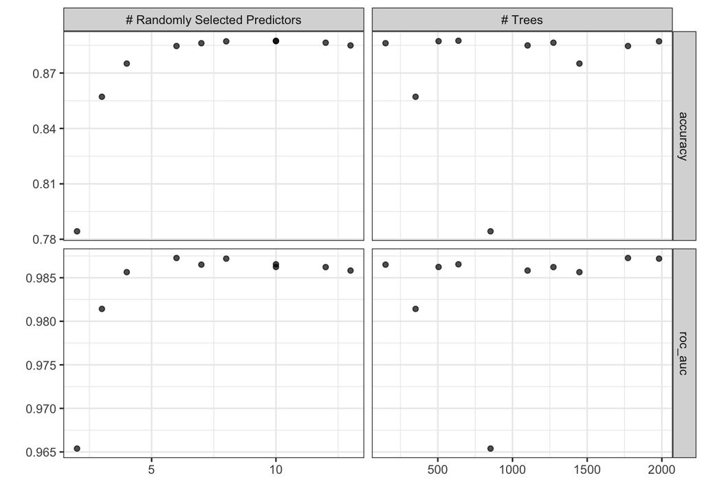

```r
autoplot(rf_cv_tune) + #plot cv results for parameter tuning
  theme_bw()
```

#### Finalize workflow

```r
rf_best = show_best(rf_cv_tune, n = 1, metric = "roc_auc") #get metrics for best random forest model
rf_best
```

```
## # A tibble: 1 × 8
##    mtry trees .metric .estimator  mean     n  std_err .config
##   <int> <int> <chr>   <chr>      <dbl> <int>    <dbl> <chr>
## 1     6  1773 roc_auc hand_till  0.987     5 0.000192 Preprocessor1_Model03
```

#### Model 5: Boosted Tree Classifier

```r
?boost_tree
```

I will be using the xgboost engine (Chen et al., 2022) for this model. The parameters I will be tuning are learn_rate and trees. learn_rate is the rate that the algorithm adapts between each tree iteration. trees is the number of tress that the model creates.

```r
xgb_model = boost_tree(learn_rate = tune(), trees = tune()) %>%
  set_engine("xgboost") %>%
  set_mode("classification")
```

```r
xgb_workflow = workflow() %>% #create workflow
  add_model(xgb_model) %>% #add boosted trees model
  add_recipe(fish_recipe) #add recipe

xgb_workflow
```

```
## ══ Workflow ════════════════════════════════════════════════════════════════════
## Preprocessor: Recipe
## Model: boost_tree()
##
## ── Preprocessor ────────────────────────────────────────────────────────────────
## 2 Recipe Steps
##
## • step_dummy()
## • step_normalize()
##
## ── Model ───────────────────────────────────────────────────────────────────────
## Boosted Tree Model Specification (classification)
##
## Main Arguments:
##   trees = tune()
##   learn_rate = tune()
##
## Computational engine: xgboost
```

##### Parameter Tuning

```r
# xgb_cv_tune = xgb_workflow %>%
#   tune_grid(resamples = cv_folds, grid = 10) #use cross validation to tune learn_rate and trees parameters
```

```r
load(file = here::here("discussion","data",  "xgb_tune.rda"))
```

```r
collect_metrics(xgb_cv_tune) #get metrics from tuning cv to pick best model
```

```
## # A tibble: 20 × 8
##    trees learn_rate .metric  .estimator  mean     n  std_err .config
##    <int>      <dbl> <chr>    <chr>      <dbl> <int>    <dbl> <chr>
##  1   583    0.00102 accuracy multiclass 0.716     5 0.00377  Preprocessor1_Mode…
##  2   583    0.00102 roc_auc  hand_till  0.933     5 0.00127  Preprocessor1_Mode…
##  3  1659    0.00184 accuracy multiclass 0.768     5 0.00309  Preprocessor1_Mode…
##  4  1659    0.00184 roc_auc  hand_till  0.961     5 0.000696 Preprocessor1_Mode…
##  5   844    0.00451 accuracy multiclass 0.779     5 0.00257  Preprocessor1_Mode…
##  6   844    0.00451 roc_auc  hand_till  0.964     5 0.000592 Preprocessor1_Mode…
##  7   359    0.00665 accuracy multiclass 0.760     5 0.00334  Preprocessor1_Mode…
##  8   359    0.00665 roc_auc  hand_till  0.957     5 0.000678 Preprocessor1_Mode…
##  9  1007    0.0123  accuracy multiclass 0.831     5 0.00232  Preprocessor1_Mode…
## 10  1007    0.0123  roc_auc  hand_till  0.978     5 0.000473 Preprocessor1_Mode…
## 11  1526    0.0285  accuracy multiclass 0.879     5 0.00115  Preprocessor1_Mode…
## 12  1526    0.0285  roc_auc  hand_till  0.986     5 0.000534 Preprocessor1_Mode…
## 13   788    0.0336  accuracy multiclass 0.863     5 0.000958 Preprocessor1_Mode…
## 14   788    0.0336  roc_auc  hand_till  0.984     5 0.000494 Preprocessor1_Mode…
## 15  1900    0.0635  accuracy multiclass 0.894     5 0.00145  Preprocessor1_Mode…
## 16  1900    0.0635  roc_auc  hand_till  0.987     5 0.000552 Preprocessor1_Mode…
## 17  1385    0.133   accuracy multiclass 0.895     5 0.00133  Preprocessor1_Mode…
## 18  1385    0.133   roc_auc  hand_till  0.987     5 0.000626 Preprocessor1_Mode…
## 19    95    0.276   accuracy multiclass 0.867     5 0.000948 Preprocessor1_Mode…
## 20    95    0.276   roc_auc  hand_till  0.985     5 0.000544 Preprocessor1_Mode…
```

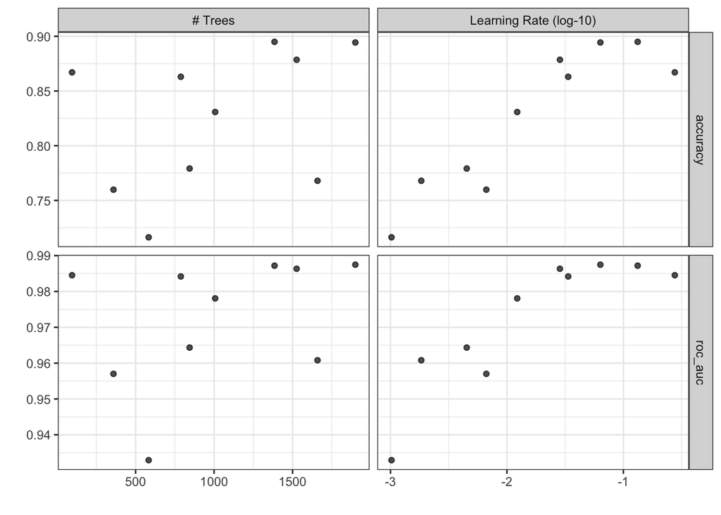

```r
autoplot(xgb_cv_tune) + #plot cv results for parameter tuning
  theme_bw()
```

#### Finalize workflow

```r
xgb_best = show_best(xgb_cv_tune, n = 1, metric = "roc_auc") #get metrics for best random forest model
xgb_best
```

```
## # A tibble: 1 × 8
##   trees learn_rate .metric .estimator  mean     n  std_err .config
##   <int>      <dbl> <chr>   <chr>      <dbl> <int>    <dbl> <chr>
## 1  1900     0.0635 roc_auc hand_till  0.987     5 0.000552 Preprocessor1_Model08
```

#### Model Fitting

```r
rf_final = finalize_workflow(rf_workflow, select_best(rf_cv_tune, metric = "roc_auc"))

xgb_final = finalize_workflow(xgb_workflow, select_best(xgb_cv_tune, metric = "roc_auc"))
```

*these all take a few seconds*

```r
train_fit_rf = fit(rf_final, train) #fit the RF model to the training set

train_fit_rf
```

```
## ══ Workflow [trained] ══════════════════════════════════════════════════════════
## Preprocessor: Recipe
## Model: rand_forest()
##
## ── Preprocessor ────────────────────────────────────────────────────────────────
## 2 Recipe Steps
##
## • step_dummy()
## • step_normalize()
##
## ── Model ───────────────────────────────────────────────────────────────────────
## Ranger result
##
## Call:
##  ranger::ranger(x = maybe_data_frame(x), y = y, mtry = min_cols(~6L,      x), num.trees = ~1773L, num.threads = 1, verbose = FALSE,      seed = sample.int(10^5, 1), probability = TRUE)
##
## Type:                             Probability estimation
## Number of trees:                  1773
## Sample size:                      37984
## Number of independent variables:  14
## Mtry:                             6
## Target node size:                 10
## Variable importance mode:         none
## Splitrule:                        gini
## OOB prediction error (Brier s.):  0.1093427
```

```r
train_fit_xgb = fit(xgb_final, train) #fit the Boosted Trees model to the training set

train_fit_xgb
```

```
## ══ Workflow [trained] ══════════════════════════════════════════════════════════
## Preprocessor: Recipe
## Model: boost_tree()
##
## ── Preprocessor ────────────────────────────────────────────────────────────────
## 2 Recipe Steps
##
## • step_dummy()
## • step_normalize()
##
## ── Model ───────────────────────────────────────────────────────────────────────
## ##### xgb.Booster
## raw: 38 Mb
## call:
##   xgboost::xgb.train(params = list(eta = 0.063458594585094, max_depth = 6,
##     gamma = 0, colsample_bytree = 1, colsample_bynode = 1, min_child_weight = 1,
##     subsample = 1), data = x$data, nrounds = 1900L, watchlist = x$watchlist,
##     verbose = 0, nthread = 1, objective = "multi:softprob", num_class = 8L)
## params (as set within xgb.train):
##   eta = "0.063458594585094", max_depth = "6", gamma = "0", colsample_bytree = "1", colsample_bynode = "1", min_child_weight = "1", subsample = "1", nthread = "1", objective = "multi:softprob", num_class = "8", validate_parameters = "TRUE"
## xgb.attributes:
##   niter
## callbacks:
##   cb.evaluation.log()
## # of features: 14
## niter: 1900
## nfeatures : 14
## evaluation_log:
##     iter training_mlogloss
##        1        1.96293903
##        2        1.86671343
## ---
##     1899        0.06678574
##     1900        0.06670658
```

```r
test_predict_rf = predict(train_fit_rf, test) %>%
  #get testing prediction
  bind_cols(test) %>%  #bind to testing column
  mutate(habitat = as.factor(habitat))

test_predict2_rf = predict(train_fit_rf, test, type = "prob") %>% #get prediction probabilities for test
  bind_cols(test) %>%  #bind to testing column
  mutate(habitat = as.factor(habitat))
```

```r
test_predict_xgb = predict(train_fit_xgb, test) %>% #get testing prediction
  bind_cols(test) %>%  #bind to testing column
  mutate(habitat = as.factor(habitat))

test_predict2_xgb = predict(train_fit_xgb, test, type = "prob") %>% #get prediction probabilities for test
  bind_cols(test) %>%  #bind to testing column
  mutate(habitat = as.factor(habitat))
```

#### Model Metrics and Evaluation

```r
accuracy(test_predict_rf, truth = habitat, estimate = .pred_class) #get accuracy of testing prediction
```

```
## # A tibble: 1 × 3
##   .metric  .estimator .estimate
##   <chr>    <chr>          <dbl>
## 1 accuracy multiclass     0.897
```

```r
accuracy(test_predict_xgb, truth = habitat, estimate = .pred_class) #get accuracy of testing prediction
```

```
## # A tibble: 1 × 3
##   .metric  .estimator .estimate
##   <chr>    <chr>          <dbl>
## 1 accuracy multiclass     0.903
```

```r
test_roc_auc_rf = roc_curve(test_predict2_rf, habitat, .pred_bathydemersal, .pred_bathypelagic, .pred_benthopelagic, .pred_demersal, .pred_pelagic, `.pred_pelagic-neritic`, `.pred_pelagic-oceanic`, `.pred_reef-associated`)
test_roc_auc_xgb = roc_curve(test_predict2_xgb, habitat, .pred_bathydemersal, .pred_bathypelagic, .pred_benthopelagic, .pred_demersal, .pred_pelagic, `.pred_pelagic-neritic`, `.pred_pelagic-oceanic`, `.pred_reef-associated`)
```

#### Visualizations

```r
m1 = test_predict_rf %>%
  conf_mat(truth = habitat, estimate = .pred_class) %>% #create confusion matrix
  autoplot(type = "heatmap") + #plot confusion matrix with heatmap
  theme_bw() + #change theme
  theme(axis.text.x = element_text(angle = 30, hjust=1)) +
  #rotate axis labels
  labs(title = "Random Forest")

m2 = test_predict_xgb %>%
  conf_mat(truth = habitat, estimate = .pred_class) %>% #create confusion matrix
  autoplot(type = "heatmap") + #plot confusion matrix with heatmap
  theme_bw() + #change theme
  theme(axis.text.x = element_text(angle = 30, hjust=1)) +
  #rotate axis labels
  labs(title = "Boosted Trees")
```

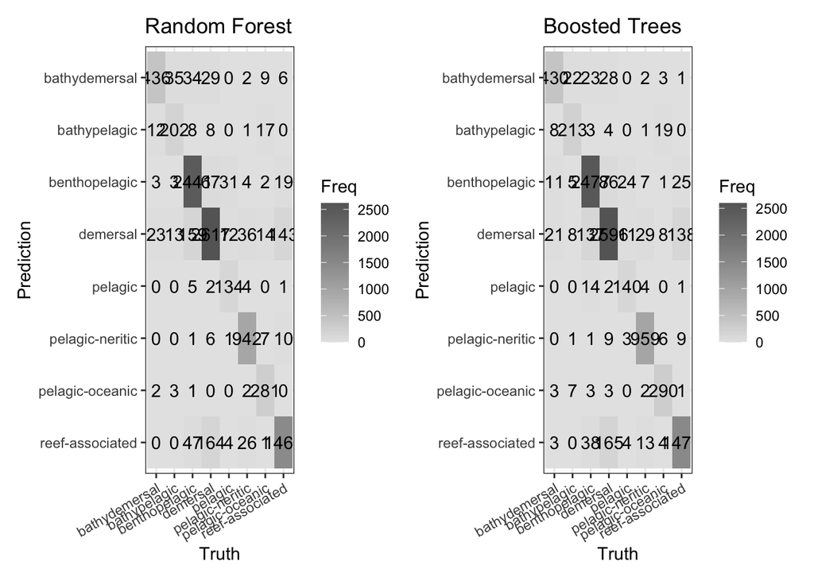

```r
m1 + m2
```

```r
r1 = autoplot(test_roc_auc_rf) +
  theme_bw() +
  labs(title = "Random Forest")

r2 = autoplot(test_roc_auc_xgb) +
  theme_bw() +
  labs(title = "Boosted Trees")
```

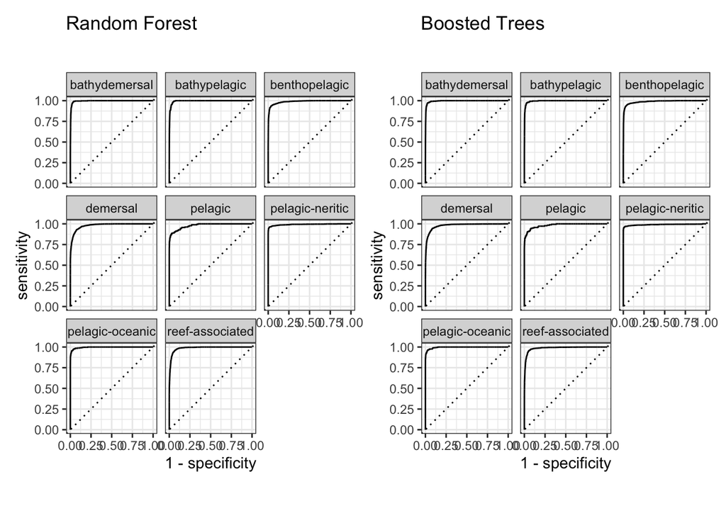

```r
r1+ r2
```